# Exploring Hindu Nationalism Discourse on Reddit through Text Analysis

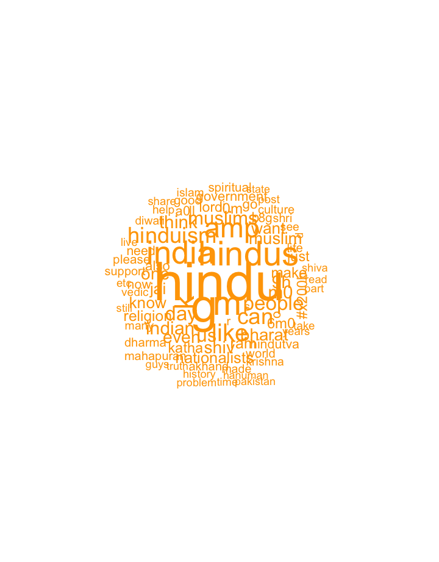

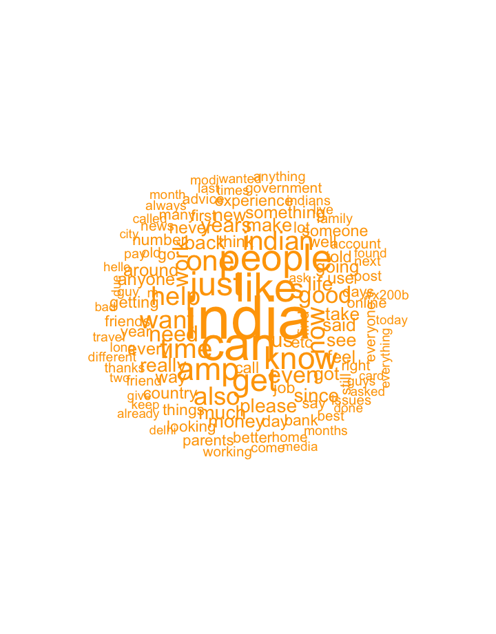

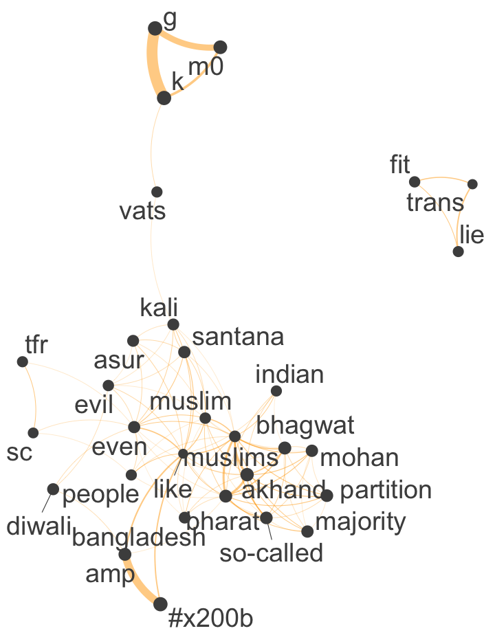

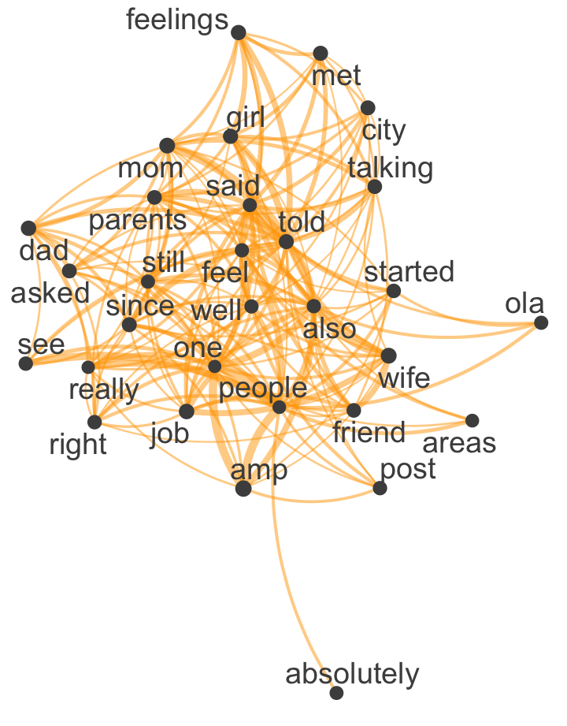

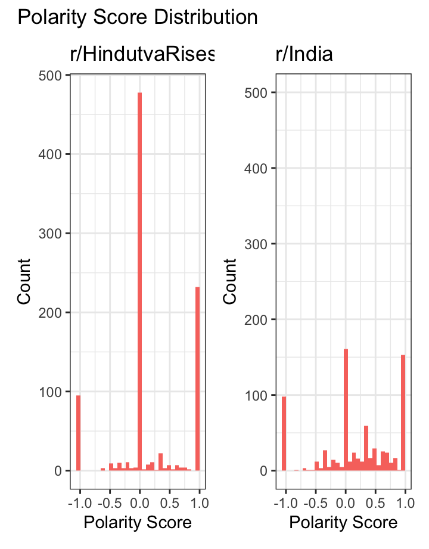

[figure not shown]

[figure not shown]

# Introduction

## Column {.data-width = 650}

### Why is it important to study this?

One of my motivations for this project is the increasing Hindu nationalistic sentiment in India. Hindu nationalism can be defined as “the collection of political thought that is spiritually underpinned by the Hindu religious and cultural traditions of India. It is important to note, as various authors point out, Hindu nationalism is not the same as Hinduism” (Siyech, 2021, p. 2). It designates Hindus as the in-group and Dalits, Muslims, and secular liberals as the out-group. At the root of Hindu nationalism is the Hindutva ideology, which “conflates geographically based cultural, national, and religious identities that focus on the manifestation of Hinduness” (Siyech, 2021, p. 2).

Historically, several events that occurred in the 70s-80s caused the strengthening of Hindu right-wing sentiments. Many right-wing publications propagated the idea that “Hindus are in danger of being overtaken by the Muslims” (Siyech, 2021, p. 5). Tensions reached a crescendo with the demolition of the Babri Mosque in 1992 (Siyech, 2021). Following this, the right-wing Bharatiya Janata Party (BJP) came to power between 1998-2004, and experienced a resurgence in support a decade after. Several factors contributed to this rise of right-wing extremism: 1) corruption within the left-wing Congress party, 2) failure of left-wing politics in India, 3) Islamist extremism in South Asia, 4) global rise of ethno-nationalism, 5) silence from the leaders, and 6) the internet’s role in facilitating this extremism by creating echo chambers (Siyech, 2021).

While the Indian government has taken steps to ban several social media channels for spreading fake political news, there has been a major growth in channels promoting extremist and nationalist views (M. N., 2023). These extremist views are manifesting in the real world too. Statistics from Hate Crime Watch showed that “91 percent of the hate crimes that have been documented in the past decade have occurred since the Modi government came to power, that is, 99 deaths and 703 wounded between May 2014 and April 2019 in crimes motivated by religious hatred (mostly of Muslims)” (Siyech, 2021, p. 3).

Reddit is the third most used social media platform in India after Facebook and Instagram, but there is limited research based on the platform’s data (Saraswat, 2022). Reddit had 3.57 million users in India in 2020 according to Statista, though it is only a fraction of other platforms of Instagram and Facebook, which are used by a staggering 349 million and 201 million users respectively (Saraswat, 2022). The structure of Reddit also varies greatly from the other two platforms, with the presence of subreddit moderators responsible for monitoring that space, rewards for discussion participation encouraging greater community engagement, and the anonymity it affords. Moderators from the r/India subreddit, the largest one pan-India, expressed their concerns with “the ineptness of the Reddit administration to understand the abuses or comments made in languages other than English” (Saraswat, 2022). They also reported a surge in hate towards minorities, primarily Muslims, Dalits, and Sikhs (Saraswat, 2022).

Hence, based on the literature identified above, this project aims to fill the gap of Reddit-based insights using text analysis methods, specifically as related to growing trends of Hindu nationalism in India.

## Column {.data-width = 350}

### Questions we’re interested in

1. What are the dominant themes discussed in prominent Indian subreddits related to the Hindutva ideology?
2. What are the dominant sentiments of users discussing the Hindutva ideology on Indian subreddits?
3. Do some Indian subreddits engage in more extreme discussions of the Hindutva ideology than others?

### What do we expect to find?

1. Some dominant themes that are discussed in Indian subreddits are related to fear of other religions, especially of Islam, and the promotion of Hindu nationalistic practices, such as cow worship.
2. The dominant sentiments in these Indian subreddits will be negative in relation to other religions and positive in relation to Hinduism.
3. Larger Indian subreddits will display a more neutral sentiment overall in their posts than smaller subreddits.

# Data and Methodology

## Column {.data-width = 650}

### What are the data used?

I used scraped data from select subreddits (r/India and r/HindutvaRises) to answer my research question using the `RedditExtractoR` package. r/India is the biggest Indian subreddit (~2 million members), and r/HindutvaRises (~6.4k members) is much smaller with a narrower focus. Both of the datasets have 8 columns: `date published`, `title`, `text`, `title_text`, `timestamp`, `number of comments`, `subreddit name`, and `url`. This analysis focuses on the `title_text` column, which was created by combining the `title` (post title) and `text` (post content) columns. While the r/India dataset has 747 rows, r/HindutvaRises has 924 rows, where each row is a post on the subreddit. Since there is a lack of literature on Reddit-based analysis of this topic, I consulted existing Reddit discussions listing the most extreme Indian subreddits, one of which was r/HindutvaRises (see https://www.reddit.com/r/unitedstatesofindia/comments/tl2fcp/rchodi_is_ded/?rdt=60857). The data used were collected on December 8th using the timeframe of a month sorted by newer posts, and so is cross-sectional data in nature. On the right are wordclouds and feature-co-occurence matrices created using these two datasets. Wordclouds are visuals that allow us to see the terms that frequently occur in our data. The bigger the term, the more prevalent they are. A feature-co-occurrence matrix connects terms that frequently occur together, which helps give us context to the terms. The thicker the connection between two terms, the more frequently they occur together.

### How will the analysis be conducted?

This project uses text analysis methods suitable for identifying frequently used terms in subreddit discussions. In particular, I’ve chosen to do a sentiment analysis of how people discuss topics related to Hindu nationalism. Topic modelling would add nuance to this analysis by identifying frequently mentioned themes and topics. I aimed to compare these subreddits to understand whether the levels of extremism and sentiment differ by the size of the subreddit.

### Audience

This dashboard is designed with a general audience in mind, one that does not know a lot about Hindu nationalism or text analysis and other technical methods. This method of visualization is easy to navigate and comprehend, since these methods can be quite abstract. Through accessible visuals attached with interpretations, this audience would be able to learn better.

### r/HindutvaRises Wordcloud

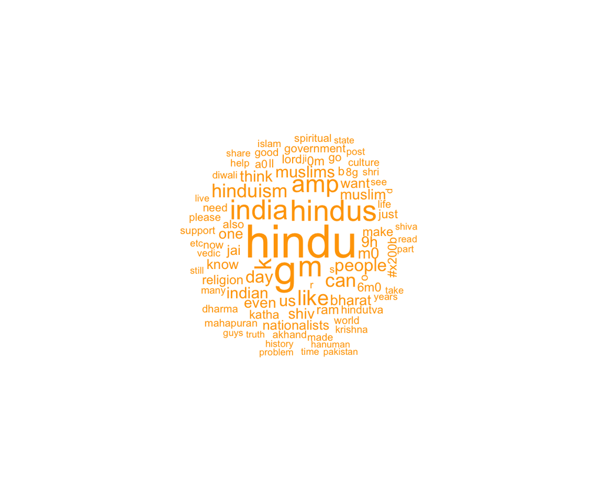

From this wordcloud, it is evident that ‘hindu’ is the most frequent word in this subreddit’s post content, followed by similar words such as ‘hindus’ and ‘hinduism’. Some words related to Hinduism are also visible, such as ‘hanuman’, ‘shiv’, and ‘ram.’ Some single letters like ‘g’, ‘m’, and ‘k’ are also frequently occuring, while could be due to accidental spaces between words. Notably, ‘muslim’ and ‘muslims’ are also frequently occurring words.

### r/India Wordcloud

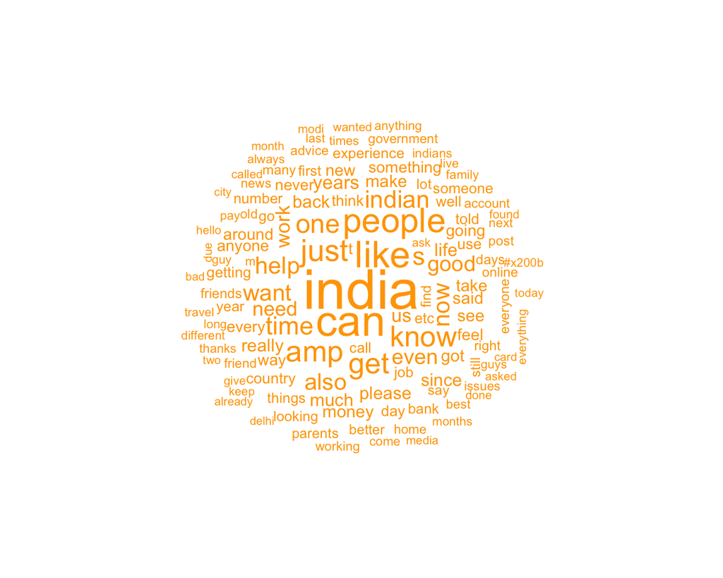

In the second wordcloud, ‘india’ is the most frequently occurring word, followed by common words such as ‘just’, ‘can’, and ‘people.’ Compared to the previous wordcloud, this one has more general terms that aren’t particularly related to religion, which makes sense since this subreddit is used as a forum for general questions.

### r/HindutvaRises Feature Co-occurrence Matrix

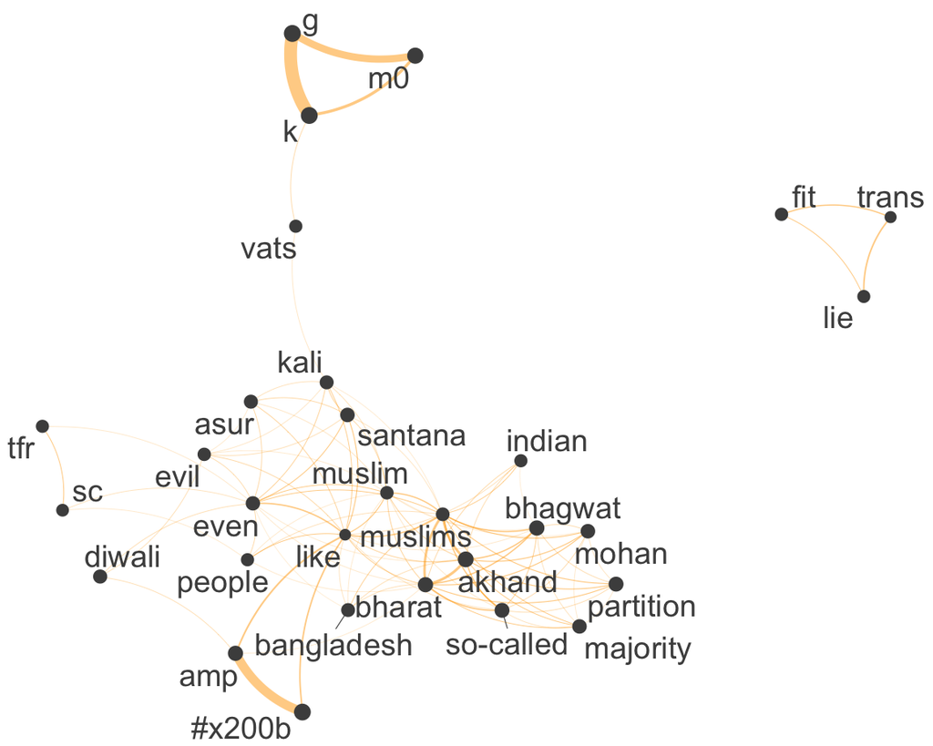

The feature-co-occurrence matrix above shows a slight fragmentation in the discussion of terms, possibly indicating the presence of echo chambers since some conversations seem to be limited to certain users. The biggest network includes commonly used Hindutva terms such as ‘akhand’ and ‘bharat’, which when used together translates to ‘Undivided India.’ This idea envisions India claim over, and intention to unify with, its neighboring countries of Bangladesh, Afghanistan, Pakistan, Myanmar, and Sri Lanka. Religious terms such as ‘diwali’, ‘asur’, and ‘kali’ have also been found to occur together. ‘#x200b’ is an anomaly in this matrix and is a unicode character code for zero-width space, and so is ‘amp’ which stands for ‘ampersand’ (&).

### r/India Feature Co-occurrence Matrix

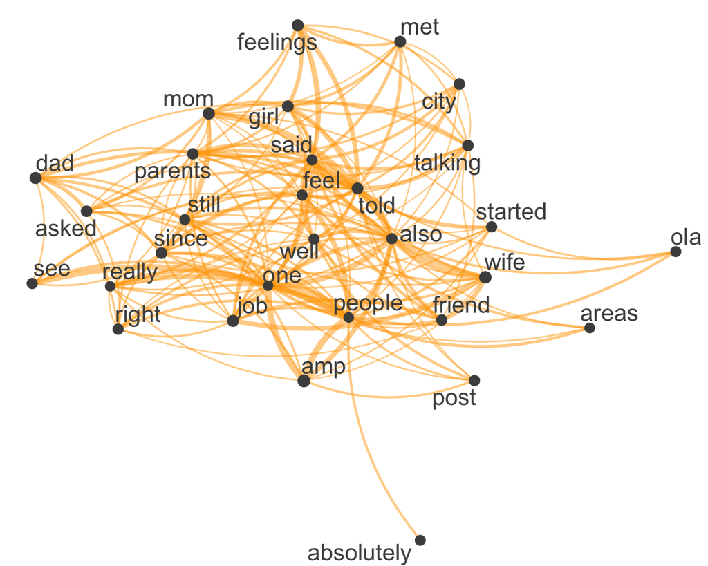

This subreddit’s co-occurrence matrix involves a lot more words commonly used in general conversations such as ‘started’, ‘people’, and ‘also’. Unlike the previous subreddit’s matrix, this network is not fragmented at all and is much more dense, suggesting a greater consensus and interconnectedness in discussions.

# Sentiment Analysis

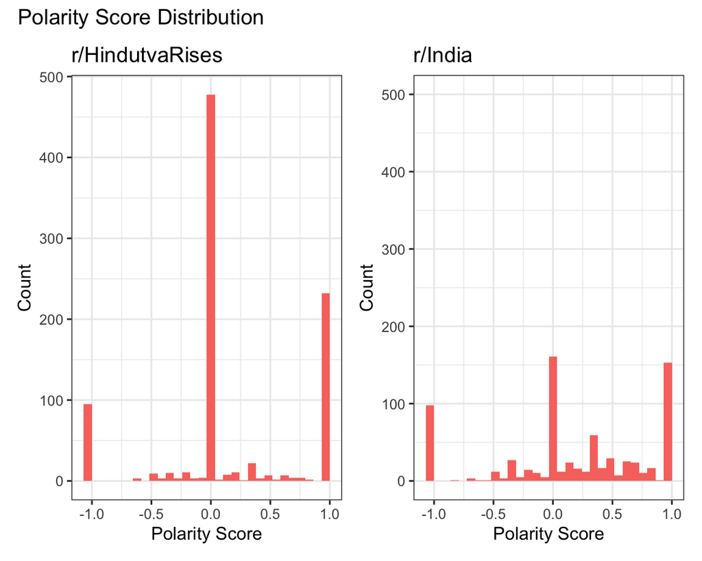

# Structural Topic Modeling

### r/HindutvaRises Topic Models

```
Topic 1 Top Words:
     Highest Prob: hindus, schools, hindu, like, can, minority, india
     FREX: schools, minority, private, rte, guru, pay, quota
     Lift: _u, #bansnapchat, #kashmirihindus, 1700s, 1830s, 19th, 20as
     Score: schools, private, rte, minority, quota, pay, hindus
Topic 2 Top Words:
     Highest Prob: amp, people, m, hinduism, india, theory, g
     FREX: theory, g, r, ancient, k, aryans, dravidians
     Lift: -jai, @0m, #art, #ayodhya, #bhaktione, #hindu, #mahabharat
     Score: theory, r, g, k, m, aryans, dravidians
Topic 3 Top Words:
     Highest Prob: hindu, nationalists, moon, india, think, page, can
     FREX: moon, fought, communities, nepal, daksha, solah, somvar
     Lift: _army, _during, _ii, _war, _world, @benga1sultanate, 00ee584382e692a1fa390a4666b62a8f864c1a3d
     Score: moon, nationalists, communities, nepal, daksha, solah, fought
Topic 4 Top Words:
     Highest Prob: ram, hindus, jai, muslims, bjp, shree, mandir
     FREX: ram, bjp, mandir, ban, remove, movies, shri
     Lift: accused, akin, ambit, anger, assertive, attend, awareness
     Score: ram, blasphemy, bjp, hindus, muslims, mandir, allies
```

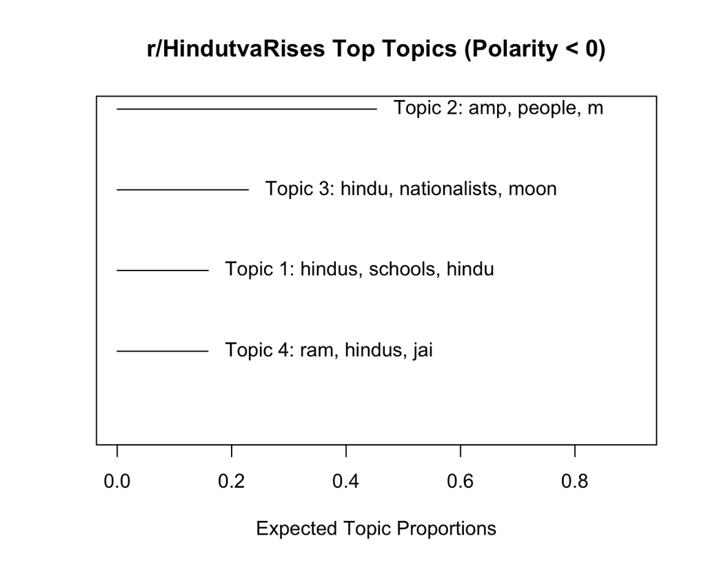

```
Topic 1 Top Words:
     Highest Prob: hindu, muslim, india, think, place, know, like
     FREX: r, support, secularism, bose, chandra, growth, subhas
     Lift: accounts, admired, bose, chandra, democracy, growth, law
     Score: growth, hindu, bose, chandra, subhas, secularism, think
Topic 2 Top Words:
     Highest Prob: g, m, k, m0, 9h, day, shiv
     FREX: g, m, k, m0, 9h, day, shiv
     Lift: @5, @hinducafe, #shiv, 0g, 2@8, 2g, 2gd
     Score: g, m, k, m0, 9h, shiv, 0m
Topic 3 Top Words:
     Highest Prob: amp, hindu, india, hinduism, people, us, hindus
     FREX: amp, us, bollywood, lanka, s, sri, akhand
     Lift: amp, arabia, battle, boi, chennakeshava, claiming, committed
     Score: amp, us, people, lanka, sri, nationalists, bollywood
Topic 4 Top Words:
     Highest Prob: like, even, dharma, santana, vedic, kali, hindus
     FREX: dharma, santana, kali, asur, well, become, evil
     Lift: 25k, 600k, abrahamic, achieve, afghanistan, agnostic, allah
     Score: santana, kali, asur, become, evil, karma, becoming
```

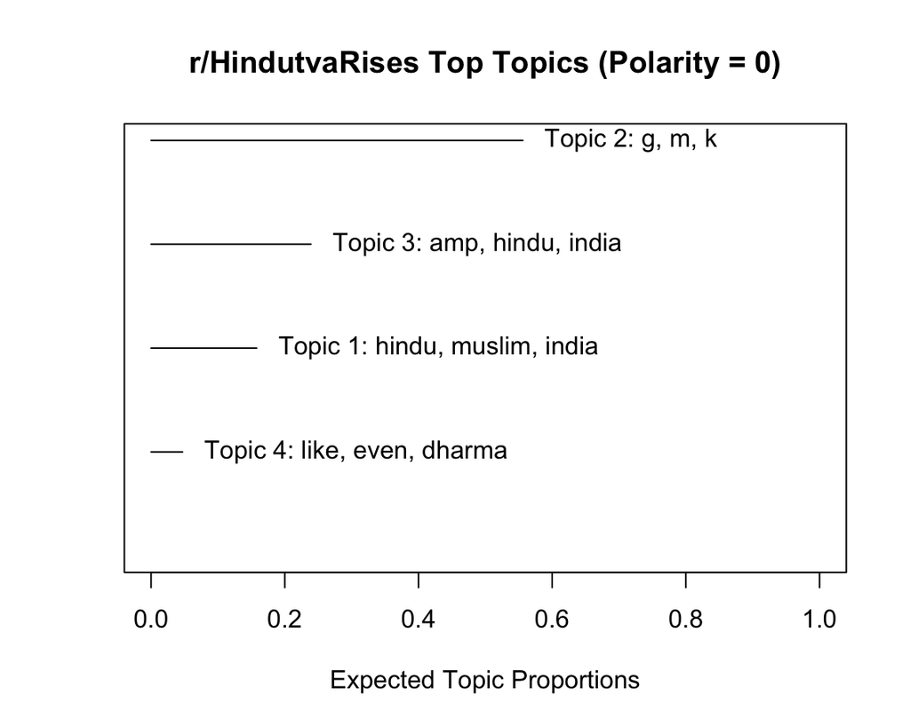

```
Topic 1 Top Words:
     Highest Prob: hindu, amp, #x200b, hinduism, want, god, hindus
     FREX: #x200b, police, army, eating, beef, pride, reading
     Lift: #x200b, 1940s, 25th, 295a, aastik, ability, abstain
     Score: #x200b, army, police, terrorists, god, eating, rise
Topic 2 Top Words:
     Highest Prob: hindu, india, muslims, hindus, akhand, bharat, trans
     FREX: trans, lie, sc, agni, census, fit, so-called
     Lift: abdul, agatsya, al, ardhnarishwar, average, avtars, bahuchar
     Score: trans, lie, sc, fit, agni, census, tfr
Topic 3 Top Words:
     Highest Prob: india, indian, hindus, us, hindu, can, calendar
     FREX: calendar, born, jai, abroad, government, hindi, break
     Lift: 10-15, 13th, 2nd, 80k, ª, aamir, abcindianhindus
     Score: calendar, government, jai, born, indian, success, retention
Topic 4 Top Words:
     Highest Prob: diwali, lord, spiritual, mukesh, vats, part, m
     FREX: diwali, mukesh, vats, g, puja, avatar, online
     Lift: @cubicalyogi, @office_sansad, @sammyvada, #hindu, #mahabharat, #mahabharata, #ramanavami
     Score: diwali, mukesh, vats, g, psychic, part, decor
```

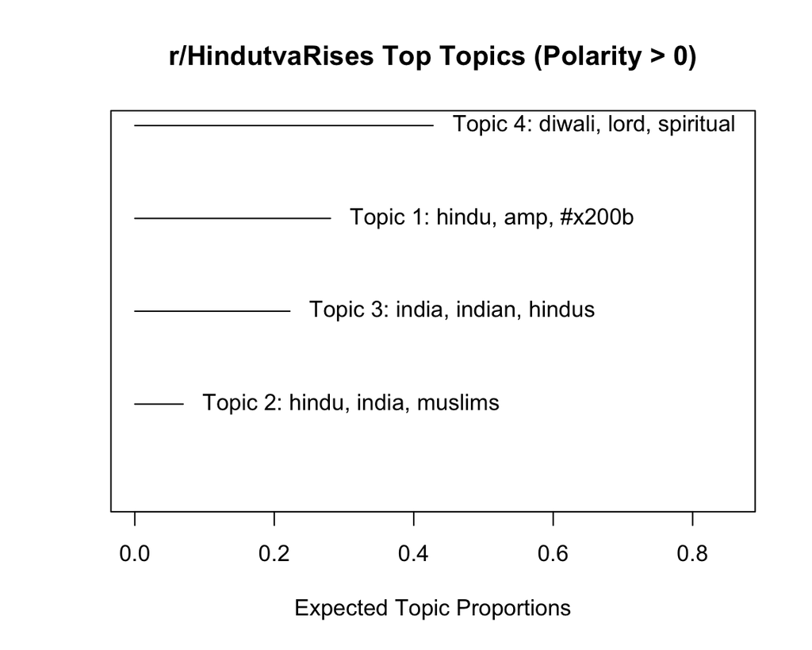

### r/India Topic Models

```
Topic 1 Top Words:
     Highest Prob: india, s, card, us, people, things, case
     FREX: livpure, congress, force, mp, bharat, cancel, research
     Lift: 100rs, 16,181-crore, 180rs, 4-hour, 5th, academic, add
     Score: livpure, cancel, 20th, rameswaram, card, add, deceptive
Topic 2 Top Words:
     Highest Prob: india, like, just, news, caste, indian, people
     FREX: caste, class, sister, agoda, brahmin, gm, man
     Lift: caste, @penpencildraw, 18m, 2019-21, 210m, 4k, 50-75ish
     Score: brahmin, agoda, attention, pakistan, class, caste, number
Topic 3 Top Words:
     Highest Prob: can, india, like, just, never, get, even
     FREX: hard, non, vegan, indians, veg, diet, image
     Lift: hard, image, _id, #hand, 0570d5348c7cb93e4b7ef69c5da4c82df0704bea, 1-2, 10-12
     Score: vegan, non, veg, hard, diet, die, try
Topic 4 Top Words:
     Highest Prob: can, parents, back, one, call, t, dad
     FREX: m, asleep, clean, hai, dream, mum, prescribed
     Lift: m, --, 12pm, 21yr, 26m, 29m, 90k
     Score: asleep, clean, prescribed, dream, mum, m, coach
```

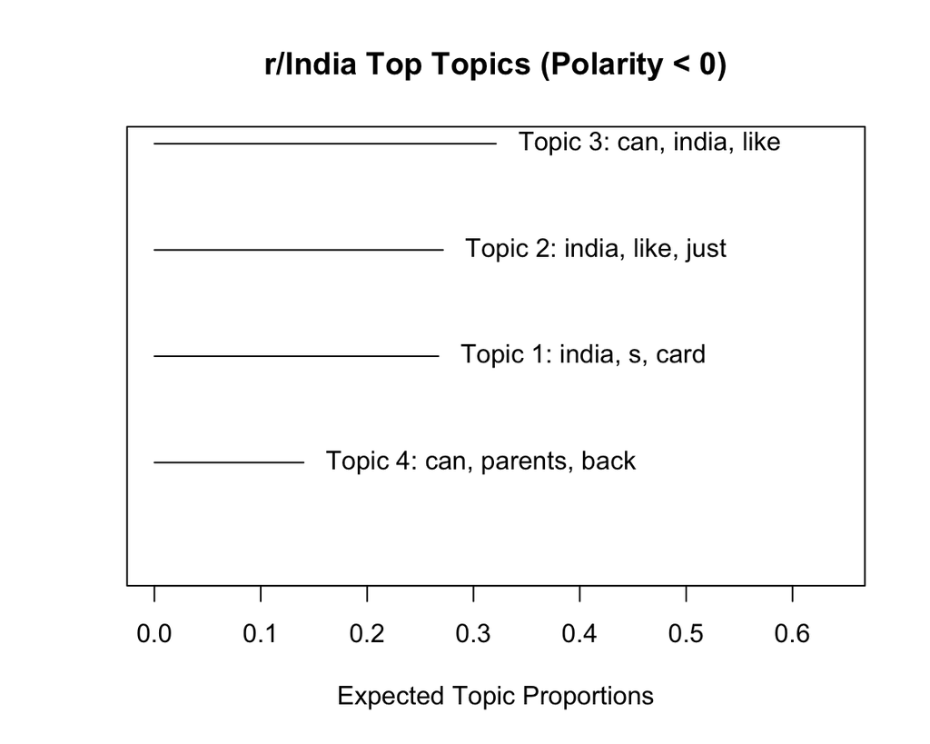

```
Topic 1 Top Words:
     Highest Prob: amp, india, indian, report, m, s, like
     FREX: report, entry, amp, format, mobile, money, two
     Lift: report, #x200b, 15k, 17mn, 25k, 97a083a86f3a9108a5ea1ab4b11849ccca670022, access
     Score: amp, sultans, tourist, visa, price, value, viewpoints
Topic 2 Top Words:
     Highest Prob: india, order, since, times, inside, use, trapped
     FREX: order, inside, use, back, decathlon, delivered, rescued
     Lift: bribes, buddha, business, currency, glovebox, songs, spray
     Score: delhi, order, decathlon, delivered, glovebox, spray, tejas
Topic 3 Top Words:
     Highest Prob: s, day, roads, people, data, just, new
     FREX: roads, data, every, many, took, avoid, go
     Lift: _names, _star, #melodi, 12th, 14-jan-1969, 1925-2023, 1st
     Score: roads, many, data, name, avoid, took, says
Topic 4 Top Words:
     Highest Prob: india, can, congress, news, s, state, old
     FREX: congress, news, state, coins, vigilance, book, city
     Lift: 32728b62cdcb3d9488e7ce24c5ab9566, 9k, accepting, accidents, adapter, bhopal, bold
     Score: congress, vigilance, commission, noise, navel, saree, wearing
```

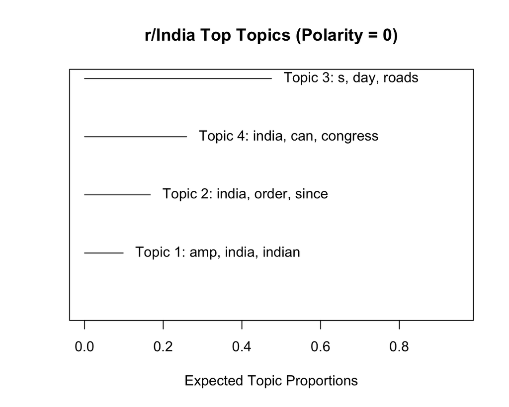

```
Topic 1 Top Words:
     Highest Prob: amp, india, people, one, like, can, just
     FREX: ama, auto, lk, named, nani, webp, indigo
     Lift: _a, _abhinandan, _abijit, _am, _dhruv, _educator, _from
     Score: ama, lk, nani, named, subsidies, cr, finals
Topic 2 Top Words:
     Highest Prob: people, india, like, just, know, can, get
     FREX: passport, coins, u, problems, nice, ve, non
     Lift: 1-2, 5th, activities, adopted, adoption, agra, aim
     Score: coins, u, wife, feelings, room, godown, representation
Topic 3 Top Words:
     Highest Prob: can, india, bank, online, help, get, account
     FREX: project, lakh, refund, zomato, gol, payments, seeking
     Lift: achieve, agent, agreement, astronaut, baby, bare, born
     Score: zomato, payments, lakh, gol, tu, academic, tashan
Topic 4 Top Words:
     Highest Prob: please, india, help, like, can, university, know
     FREX: certificate, protein, therapy, tickets, broadcasting, songs, university
     Lift: 13-place, bajpayee, bunny, censorship, clinic, didnt, dishwasher
     Score: protein, broadcasting, university, flights, forensics, universities, pet
```

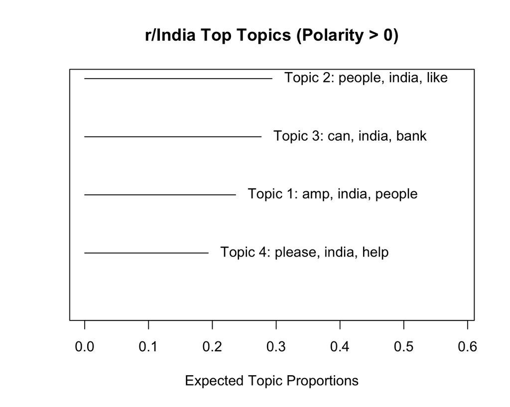

In the bigger subreddit’s model for negatively coded posts, ‘caste’ is frequently mentioned, implying disapproval of the caste system. The neutral and positive models include more general terms, such as ‘news’, ‘people’, and ‘university.’ Other than these differences, the topic models seem pretty similar even though they differ by polarity. This result complies with the overarching purpose of the subreddit, which has a large scope not limited to religious discussions unlike r/HindutvaRises.

# Conclusion and References

### Conclusion

Some limitations of this project is the limited multilingual inclusion, which could affect the result of the text analysis. The posts in these datasets indicate that a substantial amount of the text is in Hindi as transliterated to English, so existing English-based models may not pick up on some stopwords. Also, I was unable to choose a more meaningful K-value in the structural topic modeling analysis due to issues running the code. In terms of the data, it is cross-sectional in nature and only covers a month of posts. It was also not collected at a particularly relevant time period such as during elections, so it may not be very representative of the subreddits. Lastly, only two subreddits out of several were analyzed, so these results may not be applicable to all Indian subreddits.

Nevertheless, this research ventures into a lesser-explored social media in the Indian context, paving the path for more in-depth and extensive insights. Future research could compare more subreddits over a relevant time period such as during election seasons. In the structural modeling section, more experimentation with k-values could be done to find an optimal number of topics for each subreddit. The distribution of specific emotions (such as anger and happiness) in these subreddits rather than just negative and positive sentiments would be insightful as well.

### References

Chakraborty, S., Pal, J., Chandra, P., & Romero, D. M. (2018a). Political Tweets and Mainstream News Impact in India: A Mixed Methods Investigation into Political Outreach. Proceedings of the 1st ACM SIGCAS Conference on Computing and Sustainable Societies. https://doi.org/10.1145/3209811.3209825.

Manuvie, R., & Chatterjee, S. (2023). Automated Sentiment and Hate Speech Analysis of Facebook Data by Employing Multilingual Transformer Models. Computation and Language, 1–11. https://doi.org/https://doi.org/10.48550/arXiv.2301.13668.

M. N., P. (2023, February 28). India’s YouTube Vigilante is Wanted for Murder. Wired. https://www.wired.com/story/indias-youtube-vigilante-monu-manesar-murder/.

Saraswat, R. (2022, January 25). Out of Sight: How Reddit became a “safe space” for hate in India. TheQuint. https://www.thequint.com/neon/web-culture/out-of-sight-how-reddit-became-a-safe-space-for-hate.

Siyech, M. S. (2021). An Introduction to Right-Wing Extremism in India. New England Journal of Public Policy, 33(2). https://scholarworks.umb.edu/cgi/viewcontent.cgi?article=1809&context=nejpp.